# Project 1 --- Basic Principles and Models

We're going to work with the [California housing dataset](https://inria.github.io/scikit-learn-mooc/python_scripts/datasets_california_housing.html). This dataset was derived from the 1990 U.S. census, using one row per census block group. A block group is the smallest geographical unit for which the U.S. Census Bureau publishes sample data (a block group typically has a population of 600 to 3,000 people). The target variable is the median house value for California districts, expressed in hundreds of thousands of dollars ($100,000).

```python
from sklearn.datasets import fetch_california_housing
import numpy as np
import matplotlib.pyplot as plt
dataset = fetch_california_housing()
```

## Part 1: Getting started

First off, take a look at the `data`, `target` and `feature_names` entries in the `dataset` dictionary. They contain the information we'll be working with here. Then, create a Pandas DataFrame called `df` containing the data and the targets, with the feature names as column headings. If you need help, see [here](https://pandas.pydata.org/pandas-docs/stable/reference/api/pandas.DataFrame.html) for more details on how to achieve this.

- How many features do we have in this dataset? 8
- Determine the median target value. 1.797
- How many blocks have a target value greater than the median target value? 10317

Now add an additional column containing either 0 (if the target value is below the median or equal to the median) or 1 (if the target value is greater than the median). This will be the new target value to classify the data as blocks with a median house value below median or above median.

```python
import pandas as pd

df = pd.DataFrame(data=dataset.data, columns=dataset.feature_names)
df['target'] = dataset.target

# determine the median target value
median_target = df['target'].median()
print("Median target value: ", median_target)

# calculate number of rows with greater target than the median target
count_greater_target = df[df['target'] > median_target].shape[0]
print("Num blocks with greater target:", count_greater_target)

# add new column with value 1 if target is greater than median, otherwise 0
df['is_greater'] = (df['target'] > median_target).astype(int)

print(df)
```

```
Median target value:  1.797
Num blocks with greater target: 10317
       MedInc  HouseAge  AveRooms  AveBedrms  Population  AveOccup  Latitude  \
0      8.3252      41.0  6.984127   1.023810       322.0  2.555556     37.88
1      8.3014      21.0  6.238137   0.971880      2401.0  2.109842     37.86
2      7.2574      52.0  8.288136   1.073446       496.0  2.802260     37.85
3      5.6431      52.0  5.817352   1.073059       558.0  2.547945     37.85
4      3.8462      52.0  6.281853   1.081081       565.0  2.181467     37.85
...       ...       ...       ...        ...         ...       ...       ...
20635  1.5603      25.0  5.045455   1.133333       845.0  2.560606     39.48
20636  2.5568      18.0  6.114035   1.315789       356.0  3.122807     39.49
20637  1.7000      17.0  5.205543   1.120092      1007.0  2.325635     39.43
20638  1.8672      18.0  5.329513   1.171920       741.0  2.123209     39.43
20639  2.3886      16.0  5.254717   1.162264      1387.0  2.616981     39.37

       Longitude  target  is_greater
0        -122.23   4.526           1
1        -122.22   3.585           1
2        -122.24   3.521           1
3        -122.25   3.413           1
4        -122.25   3.422           1
...          ...     ...         ...
20635    -121.09   0.781           0
20636    -121.21   0.771           0
20637    -121.22   0.923           0
20638    -121.32   0.847           0
20639    -121.24   0.894           0

[20640 rows x 10 columns]
```

### Splitting the data

It is best practice to have a training set (from which there is a rotating validation subset) and a test set. Our aim here is to (eventually) obtain the best accuracy we can on the test set (we'll do all our tuning on the training/validation sets, however.)

**Split the dataset** into a train and a test set **"70:30"**, use **`random_state=1`**. The test set is set aside (untouched) for final evaluation, once hyperparameter optimization is complete.

**Only Split the dataset once within you notebook.** You should not use the `train_test_split` function more than once, regardless of the random state. Keep this in mind for your future projects as well.

```python
from sklearn.model_selection import train_test_split

train_data, test_data = train_test_split(df, test_size=0.3, random_state=1)
```

### Effect of Standardization (Visual)

Use `seaborn.lmplot` ([help here](https://seaborn.pydata.org/generated/seaborn.lmplot.html)) to visualize a few features of the training set. Draw a plot where the x-axis is `Population`, and the y-axis is `Latitude`, and the color of each datapoint indicates its class.

Standardizing the data is often critical in machine learning. Show a plot as above, but standardize the two features. What's different? **why do they look similar?** Based on your observation, what is the advantage of standardization?

- Standardization of the two features reduces the scale of both x-axis and y-axis. After standardization, the data have a common scale with a mean of 0 and a standard deviation of 1, effectively removing the original feature units.
- The scatter plots before and after standardization look similar because standardization only changes the scale but keeps the data pattern to be the same. It applies the same operation on both x-value and y-value. Therefore, the relationships between the features preserve while only removing the original units.
- Standardization creates uniformity and small-scale comparison, making it easier to identify certain values and compare them across features. It also improves the performance and training stability without altering the data patterns.

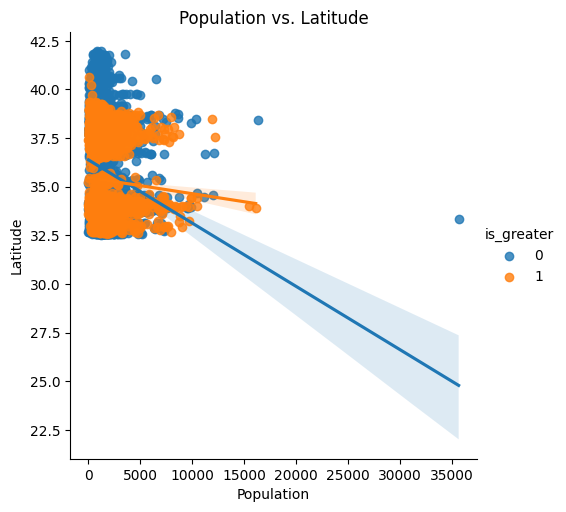

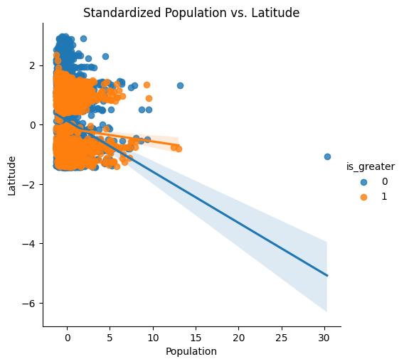

```python
import seaborn as sns
from sklearn.preprocessing import StandardScaler

sns.lmplot(data=train_data, x="Population", y="Latitude", hue="is_greater")
plt.title('Population vs. Latitude')
plt.show()

# standardize
scaler = StandardScaler()
standardized_data = train_data[['Population', 'Latitude', 'is_greater']].copy()
scaler.fit(standardized_data[['Population', 'Latitude']])
standardized_data[['Population', 'Latitude']] = scaler.transform(standardized_data[['Population', 'Latitude']])

sns.lmplot(data=standardized_data, x="Population", y="Latitude", hue="is_greater")
plt.title('Standardized Population vs. Latitude')
plt.show()
```

## Part 2: KNN Classifier without Standardization

Normally, standardizing data is a key step in preparing data for a KNN classifier. First try to build a model without standardization. Let's create a KNN classifier to predict whether the blocks have a house value less than the median or greater than the median.

Follow these steps:

1. Train a KNN Classifier using cross-validation on the dataset. Sweep `k` (number of neighbours) from 1 to 1000 (feel free to use a step size larger than 1), and show a plot of the mean cross-validation accuracy vs `k`.
2. What is the best `k`? What is the highest cross-validation accuracy?

best k = 1 with highest cv accuracy is around 0.61. 3. Comment on which ranges of `k` lead to underfitted or overfitted models (hint: compare training and validation curves!).

An overfit occurs when the k value is very small, while the training accuracy is much higher than the cross-validation accuracy, resulting in a low performance on unseen data. In this case, k = 1 to k = 10 seems to be a range that causes the overfitted model.

An underfit occurs when k value is large and both training and validation accuracies are low with a small gap between the curves. This means that the model is too simple to capture the complexity of data. In this case, k greater tha 400 indicates an underfitted model.

```
Best k:  1
Best cross-validation accuracy:  0.6098409310581481
```

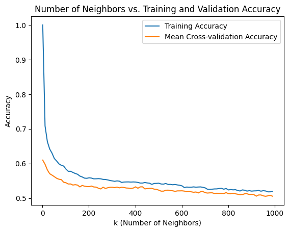

```python
from sklearn.neighbors import KNeighborsClassifier
from sklearn.model_selection import cross_val_score

X_train = train_data.iloc[:, 0:8]
y_train = train_data['is_greater']
X_test = test_data.iloc[:, 0:8]
y_test = test_data['is_greater']

k_sweep = range(1, 1001, 10)  # sweep k from 1 to 1000 with step 10
mean_cv_acc, train_acc = [], []
best_cv, best_k = 0, 1

# train KNN classifier using cross-validation for each k
for k in k_sweep:
    knn = KNeighborsClassifier(n_neighbors=k)

    # calculate training accuracy
    knn.fit(X_train, y_train)
    train_score = knn.score(X_train, y_train)
    train_acc.append(train_score)

    # calculate mean cross-validation accuracy
    cv_score = cross_val_score(knn, X_train, y_train, cv=5, scoring='accuracy').mean() # cv of 5 folds
    if cv_score > best_cv:
        best_cv = cv_score
        best_k = k
    mean_cv_acc.append(cv_score)

print("Best k: ", best_k)
print("Best cross-validation accuracy: ", best_cv)

# plot training and validation accuracy curves vs k
plt.plot(k_sweep, train_acc, label='Training Accuracy')
plt.plot(k_sweep, mean_cv_acc, label='Mean Cross-validation Accuracy')
plt.title('Number of Neighbors vs. Training and Validation Accuracy')
plt.xlabel('k (Number of Neighbors)')
plt.ylabel('Accuracy')
plt.legend()
plt.show()
```

## Part 3: Feature Selection

In this part, we aim to investigate the importance of each feature on the final classification accuracy. If we want to try every possible combination of features, we would have to test $2^F$ different cases, where F is the number of features, and in each case, we have to do a hyperparameter search (finding K, in KNN using cross-validation). That will take days!.

To find more important features we will use a decision tree. based on a decision tree we can compute feature importance that is a metric for our feature selection (code is provided below).

You can use [this link](https://machinelearningmastery.com/calculate-feature-importance-with-python/) to get familiar with extracting the feature impotance order of machine learning algorithms in Python.

After we identified and removed the least important feature and evaluated a new KNN model on the new set of features, if the stop conditions (see step 7 below) are not met, we need to repeat the process and remove another feature.

Design a function ( `Feature_selector`) that accepts your dataset (X_train , y_train) and a threshold as inputs and:

1. Fits a decision tree classifier on the training set.
2. Extracts the feature importance order of the decision tree model.
3. Removes the least important feature based on step 2.
4. Then, a KNN model is trained on the remaining features. The number of neighbors (`k`) for each KNN model should be tuned using a 5-fold cross-validation.
5. Store the best `mean cross-validation` score and the corresponding `k` (number of neighbours) value in two lists.
6. Go back to step 3 and follow all the steps until you meet the stop condition (step 7).
7. We will stop this process when (1) there is only one feature left, or (2) our cross-validation accuracy is dropped significantly compared to a model that uses all the features. In this function, we accept a threshold as an input argument. For example, if threshold=0.95 we do not continue removing features if our mean cross-validation accuracy after tuning `k` is bellow **0.95 $\times$ Full Feature cross-validation accuracy**.
8. Your function returns the list of removed features, and the corresponding mean cross-validation accuracy and `k` value when a feature was removed.
- Visualize your results by plotting the mean cross-validation accuracy (with a tuned `k` on y axis) vs. the number of features (x axis). This plot describes: what is the best cv score with 1 feature, 2 features, 3 features ... and all the features.
- Plot the best value of `k` (y-axis) vs. the number of features. This plot explains the trend of number of neighbours with respect to the number of features.
- State what is the number of essential features for classification and justify your answer.

You can use the following piece of code to start training a decision tree classifier and obtain its feature importance order.

```
from sklearn import tree
dt = tree.DecisionTreeClassifier()
dt.fit(X_train,y_train)
importance = dt.feature_importances_
```

```python
from sklearn import tree

# find the best cv score and k value using KNN
def Find_best_k(X_train, y_train, k_range=(1, 101, 5)):
    best_cv = 0
    best_k = 1
    for k in range(*k_range):
        knn = KNeighborsClassifier(n_neighbors=k)
        cv_score = cross_val_score(knn, X_train, y_train, cv=5).mean()
        if cv_score > best_cv:
            best_cv = cv_score
            best_k = k
    return best_cv, best_k

def Feature_selector (X_train , y_train , tr=0.95):
    n_features = X_train.shape[1]  # number of remaining features
    features = list(X_train.columns)  # list of remaining feature names
    removed_features, cv_scores, best_ks = [], [], []

    dt = tree.DecisionTreeClassifier()
    dt.fit(X_train, y_train)

    full_cv_score = cross_val_score(KNeighborsClassifier(), X_train, y_train, cv=5).mean()
    best_cv = full_cv_score

    # feature selection process
    while len(features) > 1 and best_cv >= tr * full_cv_score:
        dt.fit(X_train[features], y_train) # fit decision tree
        importance = dt.feature_importances_ # get feature importances

        # remove the least important feature
        least_important = features[importance.argmin()]
        removed_features.append(least_important)
        features.remove(least_important)

        # find the best cv and k
        best_cv, best_k = Find_best_k(X_train[features], y_train)

        # store the best results for the current number of features
        cv_scores.append(best_cv)
        best_ks.append(best_k)

    return removed_features, cv_scores, best_ks
```

```python
removed_features, cv_scores, best_ks = Feature_selector(X_train, y_train, tr=0.95)

print("Removed Features: ", removed_features)
print("Cross-validation Scores: ", cv_scores)
print("Best k values: ", best_ks)
```

```
Removed Features:  ['Population', 'AveBedrms', 'HouseAge', 'AveRooms', 'AveOccup', 'Latitude', 'Longitude']
Cross-validation Scores:  [0.8472457633716244, 0.8471072592496774, 0.8723007805528906, 0.8723701523856748, 0.8585963941498657, 0.8037786329485066, 0.7445321413642727]
Best k values:  [16, 16, 11, 11, 11, 31, 71]
```

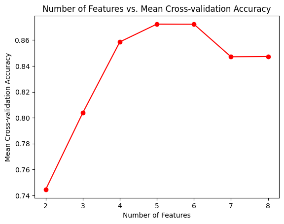

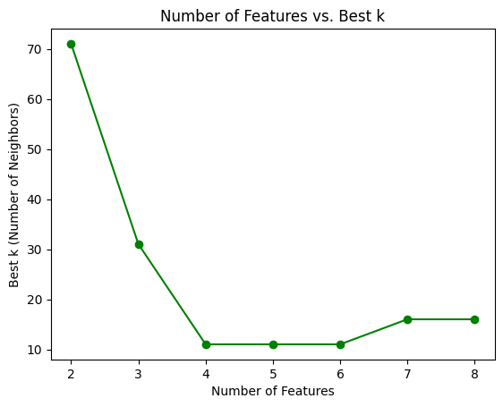

```python
# get the number of features remaining at each step
num_features = [len(X_train.columns) - i for i in range(len(removed_features))]

# plot Number of Features vs. Mean Cross-validation Accuracy
plt.plot(num_features, cv_scores, marker='o', color='r')
plt.xlabel("Number of Features")
plt.ylabel("Mean Cross-validation Accuracy")
plt.title("Number of Features vs. Mean Cross-validation Accuracy")
plt.show()

# plot Number of Features vs. Best k
plt.plot(num_features, best_ks, marker='o', color='g')
plt.xlabel("Number of Features")
plt.ylabel("Best k (Number of Neighbors)")
plt.title("Number of Features vs. Best k")
plt.show()
```

## Part 4: Standardization

Standardizing the data usually means scaling our data to have a mean of zero and a standard deviation of one.

**Note:** When we standardize a dataset, do we care if the data points are in our training set or test set? Yes! The training set is available for us to train a model - we can use it however we want. The test set, however, represents a subset of data that is not available for us during training. For example, the test set can represent the data that someone who bought our model would use to see how the model performs (which they are not willing to share with us). Therefore, we cannot compute the mean or standard deviation of the whole dataset to standardize it - we can only calculate the mean and standard deviation of the training set. However, when we sell a model to someone, we can say what our scalers (mean and standard deviation of our training set) was. They can scale their data (test set) with our training set's mean and standard deviation. Of course, there is no guarantee that the test set would have a mean of zero and a standard deviation of one, but it should work fine.

**To summarize: We fit the StandardScaler only on the training set. We transform both training and test sets with that scaler.**

1. Standardize the training and test data ([Help](https://scikit-learn.org/stable/modules/preprocessing.html))
2. Call your `Feature_selector` function on the standardized training data with a threshold of 95%.
- Plot the Cross validation accuracy when we have the standardized data (this part) and the original training data (last part) vs. the Number of features in a single plot (to compare them easily).
3. Discuss how standardization (helped/hurt) your model and its performance? Discuss which cases lead to a higher cross validation accuracy (how many features? which features? What K?)

```
Removed Features Standardized:  ['Population', 'AveBedrms', 'HouseAge', 'AveRooms', 'AveOccup', 'Latitude', 'Longitude']
Cross-validation Scores Standardized:  [0.8493914993155041, 0.8495294764414837, 0.8666944537267598, 0.8781147916988553, 0.8574890558507932, 0.8029482789389654, 0.7441860726943028]
Best k values Standardized:  [11, 11, 11, 11, 11, 71, 71]
```

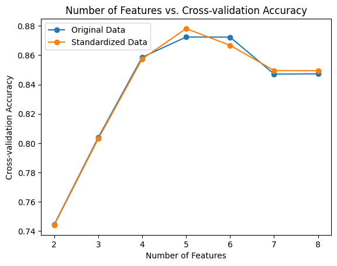

```python
# standardization
scaler = StandardScaler()
X_train_scaled = scaler.fit_transform(X_train)
X_test_scaled = scaler.transform(X_test)
X_train_scaled = pd.DataFrame(X_train_scaled, columns=X_train.columns)

removed_features_standardized, cv_scores_standardized, best_ks_standardized = Feature_selector(X_train_scaled, y_train, tr=0.95)
print("Removed Features Standardized: ", removed_features_standardized)
print("Cross-validation Scores Standardized: ", cv_scores_standardized)
print("Best k values Standardized: ", best_ks_standardized)

num_features_standardized = [len(X_train.columns) - i for i in range(len(removed_features_standardized))]

# plot cv accuracy for both original and standardized data
plt.plot(num_features, cv_scores, label='Original Data', marker='o')
plt.plot(num_features_standardized, cv_scores_standardized, label='Standardized Data', marker='o')
plt.xlabel('Number of Features')
plt.ylabel('Cross-validation Accuracy')
plt.title('Number of Features vs. Cross-validation Accuracy')
plt.legend()
plt.show()
```

## Part 5: Decision Tree Classifier

Train a decision tree classifier on the standardized dataset (read the [documentation](https://scikit-learn.org/stable/modules/generated/sklearn.tree.DecisionTreeClassifier.html) and check the example there.) Tune the `max_depth` and `min_samples_split` parameters of the tree using cross-validation (CV).

- Compare the decision tree's performance (mean CV score) with KNN, both using all the features.

The decision tree generates a better performance than KNN. Shown by the outputs, the mean cv score of decision tree is 0.8497, which is higher than 0.8355, the mean cv score of KNN. In this case, I tuned the parameters to find the best score and concluded to have the max depth and min sample split of the decision tree to be 12 and 7 respectively. The best k for KNN is 16.

```python
# Decision Tree
dt_standardized = tree.DecisionTreeClassifier()
tree_best_cv = 0
tree_best_params = {}

for depth in range(1, 20):
    for split in range(2, 10):
        # create decision tree model
        dt_standardized.set_params(max_depth=depth, min_samples_split=split)
        cv_scores = cross_val_score(dt_standardized, X_train_scaled, y_train, cv=5, scoring='accuracy')
        mean_cv = np.mean(cv_scores)

        # compare cv scores and set the best values
        if mean_cv > tree_best_cv:
            tree_best_cv = mean_cv
            tree_best_params = {'max_depth': depth, 'min_samples_split': split}

# KNN
knn_best_cv, knn_best_k = Find_best_k(X_train_scaled, y_train)

# output the performance of the decision tree with KNN
print(f"Decision Tree Mean CV Score: {tree_best_cv:.4f}")
print(f"Decision Tree Best Parameters: {tree_best_params}")
print(f"KNN Mean CV Score: {knn_best_cv:.4f}")
print(f"KNN Best Parameters: {knn_best_k}")
```

```
Decision Tree Mean CV Score: 0.8497
Decision Tree Best Parameters: {'max_depth': 12, 'min_samples_split': 7}
KNN Mean CV Score: 0.8355
KNN Best Parameters: 16
```

## Part 6: Test Data

Now that you've created several models, pick your best one (highest CV accuracy) and apply it to the test dataset you had initially set aside. Discuss your results.

```python
# use the model from part 4
# retain 5 features after removing the least important 3
remaining_features = X_train_scaled.columns.difference(removed_features_standardized[:3])
X_train_selected = X_train_scaled[remaining_features]
X_test_selected = pd.DataFrame(X_test_scaled, columns=X_train.columns)[remaining_features]

# apply KNN model on the selected features using the best k value 11
best_k = 11
knn_final = KNeighborsClassifier(n_neighbors=best_k)
knn_final.fit(X_train_selected, y_train)

# test data prediction
y_pred_test = knn_final.predict(X_test_selected)

# calculate the percentage accuracy
performance = 100 * (1 - sum(abs(y_pred_test - y_test)) / len(y_pred_test))

print(f"Test data performance: {performance:.2f}% correctly predicted")
```

```
Test data performance: 86.71% correctly predicted
```

References:

https://towardsdatascience.com/decision-trees-in-machine-learning-641b9c4e8052

https://www.analyticsvidhya.com/blog/2021/02/machine-learning-101-decision-tree-algorithm-for-classification/